# Searching best parameter for the in-lab exp

OSCAR

2018 Feb. 12

# 1 Hypothesis

According to the model with only type I functional response, I predict that total animal density at the equilibrium ($Z_{tot}$) first increase and then decrease with intra-guild predation ($\alpha$; the proportion of IG prey that is available to the IG predator). Therefore I hypothesize that *resoure density* at the equilibrium would first decrease and then increase with contact probability ($\alpha$=0). Note that I normalized the resource density at the equilibrium on the condition where contact probability ($\alpha$=0), so that it is comparable across model and experimental results.

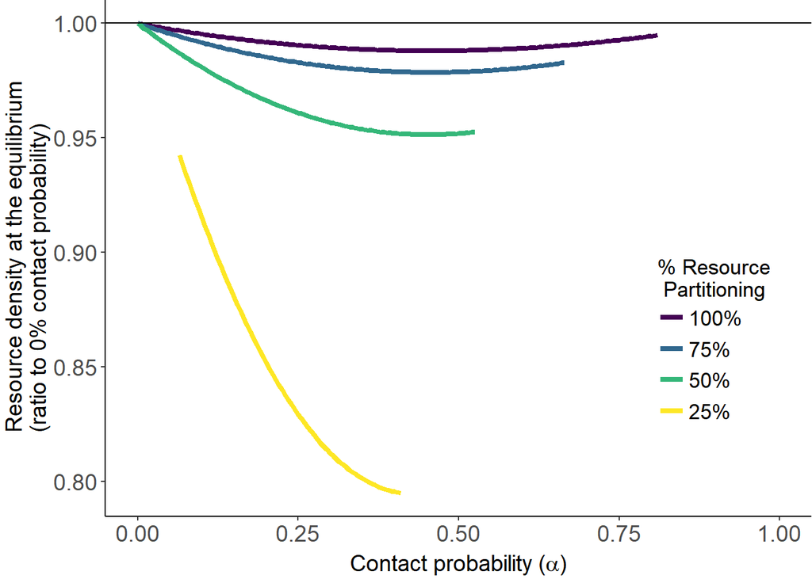

To test this hypothesis, I designed an experiment that manipulates the contact probability by installing a $10 \mu m$screen mesh that is permeable to IG prey but not IG predator. With the screen mesh, I manipulated the contact probability of the IG prey by varying the proportion of IG prey that is available to IG predator.

# 2 Experimental Results

Before confronting the data with model results, I first visualize the population dynamics of IG prey and predator.

## 2.1 Population dynamics visualization

First I used the population density of IG predator and IG prey to identify if the system reached the steady state.

IG predator *Blepharisma*

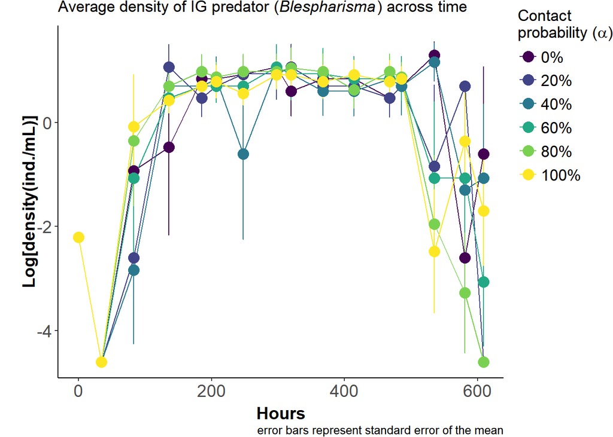

IG prey *Colpidium*

[figure not shown]

For both *Blespharisma* and *Colpidium*, I calculated the mean density for all six treatments (0%, 20%, 40%, 60%, 80% and 100% encounter probability) at the steady state. Because I cannot be 100% sure what are the most representative time points for the steady state, I calculate the mean density of every five consecutive time points. I then moved this five-point time frame gradually forward from hour 34 to hour 535. Finally , I chose the time frame of hour 320 to 486 since the other time frames are qualitatively the same.

# 3 Confronting model with empirical data

Now I overlay the model predictions onto the IG predator, IG prey, and resource density at the equilibrium measured in empirical experiment.

## 3.1 Type I model

**IG predator (*Blepharisma*)**

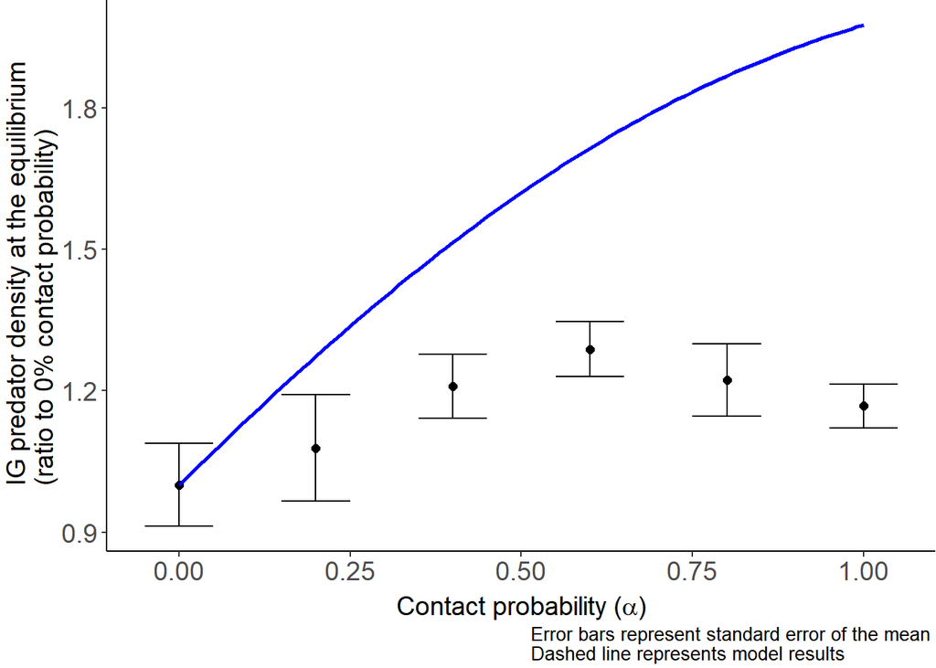

For the IG predator, the model with type I functional response explains 0% of the empirical data. **IG prey (*Colpidium*)**

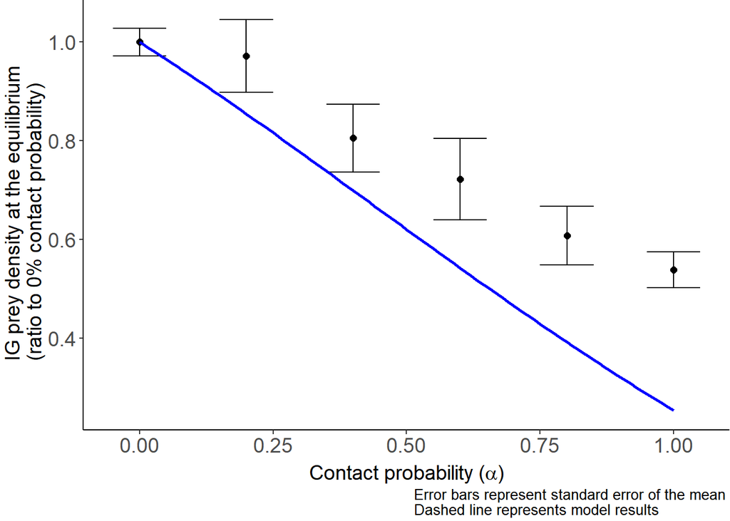

For the IG prey, the model with type I functional response explains 0% of the empirical data.

**Bacteria (resource)**

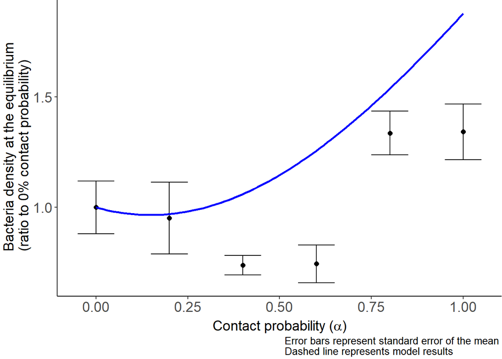

For the Bacteria, the model with type I functional response explains 0% of the empirical data.

The empirical data only qualitatively confirm the IG prey and resource density at the equilibrium and the R^2 is fairly low. The IG predator density at the equilibrium can not be described by the model with just type I functional response.

## 3.2 Type II model

From the literature[@Laybourn1975; @Fenchel1980], I found that both IG predator and IG prey have type II functional response when consuming bacteria. However, attack rate and handling time of IG predator are not specifically estimated. I therefore extracted the attack rate and handling time from [@Laybourn1975] for IG prey and used similar value for IG predator to build another more mechanistic model.

In addition, I did another independent experiment to estimate the attack rate and handling time for IG predator when consuming IG prey.

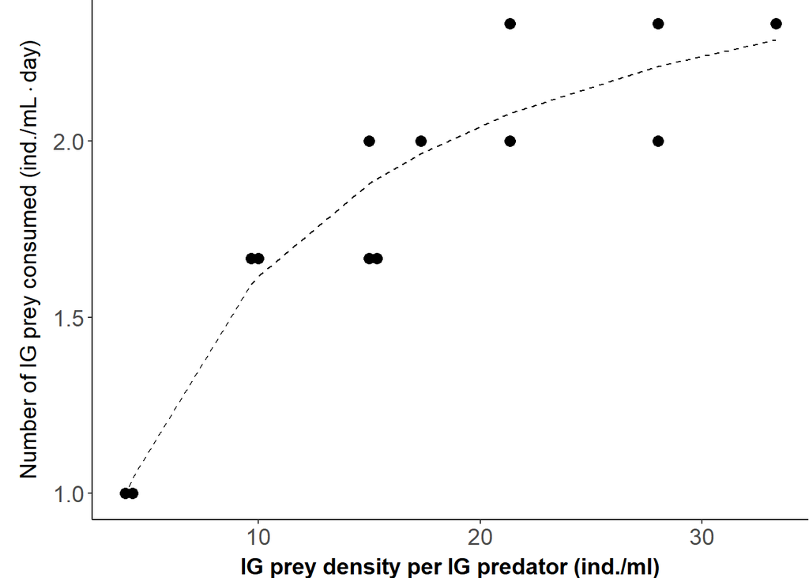

The attack rate and the handing time for IG predator when consuming IG prey are estimated to be 0.3858 and 0.3596 respectively. This means the maximum consumption per day should be 2.7809 (IG prey/IG predator) and the half saturation density of IG prey is 7.2081.

However, I cannot find empirical parameter values for the assimilation efficienty of IG prey and the degree of resource partitioning. I search for a range of parameter space to find a combination of IG prey assimilation efficienty and degree of resource partitioning that renders the lowest residual sum of squared.

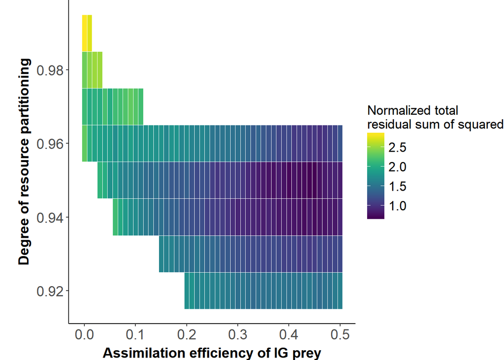

With these parameter values, I overlay the model prediction and data again.

**IG predator (*Blepharisma*)**

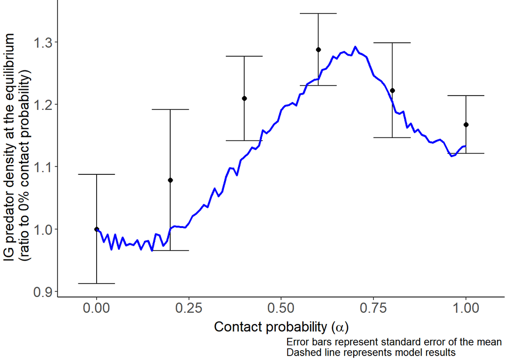

For the IG predator, the model with type II functional response explains 66.18% of the empirical data. **IG prey (*Colpidium*)**

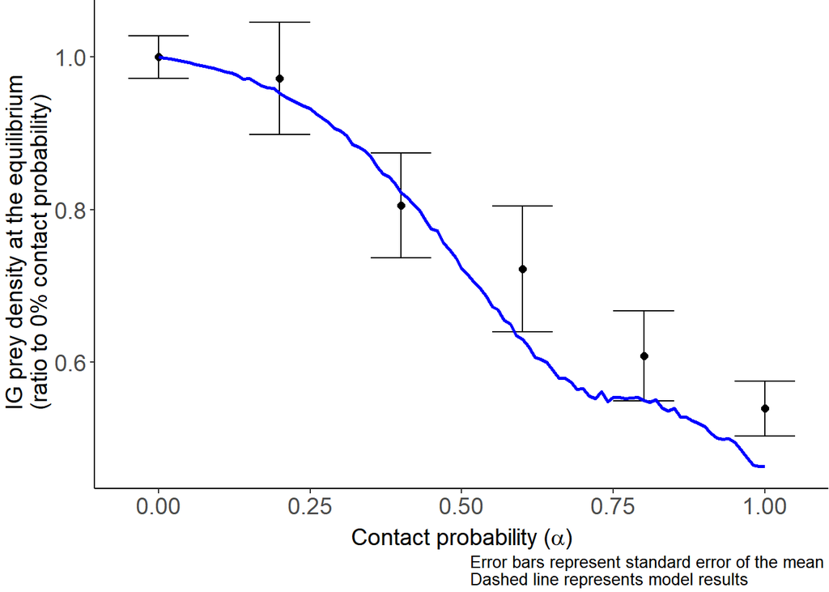

For the IG prey, the model with type II functional response explains 89.6% of the empirical data.

**Bacteria (resource)**

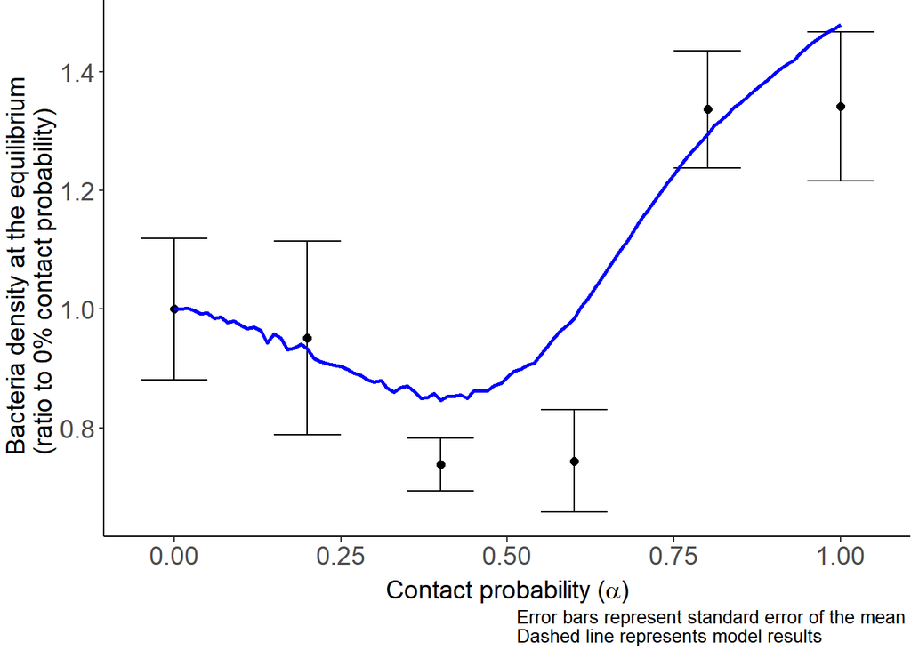

For the Bacteria, the model with type II functional response explains 0% of the empirical data.

# 4 Explanation